# P4_01_notebook_preprocessing-modelisation

### Résultats

```python
# print classification report
get_score(y_test_us, pred_forest)
```

```
              precision    recall  f1-score   support

         0.0       0.79      0.87      0.83      2186
         1.0       0.86      0.77      0.81      2186

    accuracy                           0.82      4372
   macro avg       0.82      0.82      0.82      4372
weighted avg       0.82      0.82      0.82      4372


[[1912  274]
 [ 508 1678]]
```

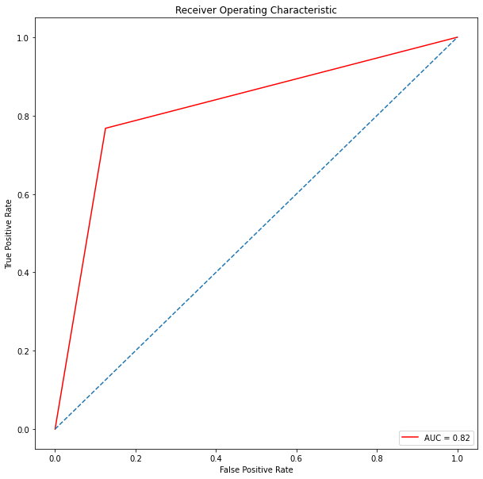

```
L'aire sous la courbe ROC :  0.8211344922232388
```

```python
draw_auroc(y_test_us, pred_forest)
```

### Amélioration du modèle - entraînement sur le dataset complet avec les meilleurs hyperparamètres

```python
# On affiche les résultats
show_best(forest_grid)
```

```
Best parameters : {'model__max_depth': 8, 'model__max_features': 'sqrt', 'model__n_estimators': 200}
Best score : 0.9131939363971092
```

```python
forest_tuned = RandomForestClassifier(
    max_depth = forest_grid.best_params_["model__max_depth"],
    max_features = forest_grid.best_params_["model__max_features"],
    n_estimators = forest_grid.best_params_["model__n_estimators"]
)

forest_tuned.fit(X_train, y_train)
```

```
RandomForestClassifier(max_depth=8, max_features='sqrt', n_estimators=200)
```

```python
pred_forest_tuned = forest_tuned.predict(X_test)
```

```python
get_score(y_test, pred_forest_tuned)
```

```
              precision    recall  f1-score   support

         0.0       0.93      1.00      0.97     28271
         1.0       1.00      0.08      0.14      2186

    accuracy                           0.93     30457
   macro avg       0.97      0.54      0.55     30457
weighted avg       0.94      0.93      0.91     30457


[[28271     0]
 [ 2018   168]]
```

### Résultats

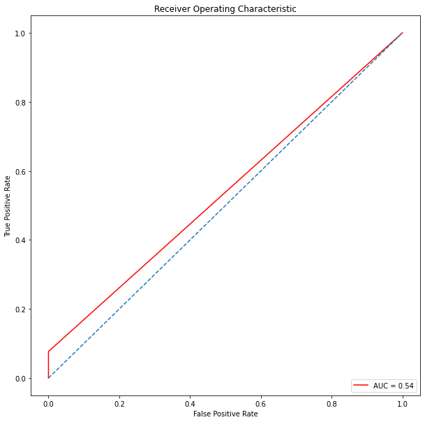

```
L'aire sous la courbe ROC :  0.5384263494967978
```

```python
draw_auroc(y_test, pred_forest_tuned)
```

## Logistic Regression

### Définition

La régression logistique est un modèle mathématique qui combine un ensemble de variables prédictives (X) avec une variable aléatoire binomiale (Y).

La régression est une technique de **modélisation linéaire**, qui étudie le rapport entre une variable principale et des variables explicatives. Elle est dite logistique, quand il existe un lien de fonction logistique entre la variable d'intérêt et les autres variables ([source](https://www.journaldunet.fr/web-tech/guide-de-l-intelligence-artificielle/1501909-regression-logistique-definition-et-cas-d-usage/)).

[figure not shown]

Représentations d'une regression logistique ([source](https://guidesurvie.com/conseils-survie/prediction-de-survie-du-titanic-a-laide-de-lapprentissage-automatique/))

### Recherche des hyperparamètres

- `l1_ratio` : nombre compris entre 0 et 1. Il donne le ratio de la régularisation l1 vs la régularisation l2.
- `C` : inverse du coefficient de régularisation.

### LogisticRegression - GridSearch

```python
lr_model = LogisticRegression(
    class_weight="balanced",
    random_state=42)
```

```python
pipe = imbpipeline([
    ('scaler', RobustScaler()),
    ('model', lr_model)
])

params = {
        "model__penalty": ['l1','l2'],
        "model__l1_ratio": [0, 0.25, 0.5, 0.75, 1],
        "model__C": np.logspace(-3, 3, 7)
}

# Création du model qui va nous permettre de comparer nos jeux de données
lr_gs = GridSearchCV(
    pipe,
    params,
    cv = 4,
    scoring = score,
    n_jobs = -1, verbose = 1)
```

```python
lr_gs.fit(X_train_us, y_train_us)
```

```
Fitting 4 folds for each of 70 candidates, totalling 280 fits
```

[output not shown]

[output cut: 1145 more lines]

[output not shown]

```
GridSearchCV(cv=4,
             estimator=Pipeline(steps=[('scaler', RobustScaler()),
                                       ('model',
                                        LogisticRegression(class_weight='balanced',
                                                           random_state=42))]),
             n_jobs=-1,
             param_grid={'model__C': array([1.e-03, 1.e-02, 1.e-01, 1.e+00, 1.e+01, 1.e+02, 1.e+03]),
                         'model__l1_ratio': [0, 0.25, 0.5, 0.75, 1],
                         'model__penalty': ['l1', 'l2']},
             scoring='roc_auc', verbose=1)
```

### Résultats

```python
show_best(lr_gs)

#df_result = pd.DataFrame(lr_gs.cv_results_)
#df_result[['param_model__C','param_model__penalty','mean_test_score']]
```

```
Best parameters : {'model__C': 1000.0, 'model__l1_ratio': 0, 'model__penalty': 'l2'}
Best score : 0.7676836943399626
```

Une fois le modèle entraîné, nous allons nous en servir pour prédire la probabilité de la non-solvabilité. La méthode `predict.proba` permet d'obtenir deux colonnes : la première correspondant à la probabilité que la cible soit `TN` (donc 0) et la seconde correspondant aux `TP` (les 1).

Nous allons donc sélectionner la seconde colonne `[:,1]` car notre objectif est de détecter les défauts de paiement (`TARGET`==1).

```python
# On récupère la prédiction de la valeur positive
y_prob = lr_gs.predict_proba(X_test_us)[:,1]
```

```python
# On créé un vecteur de prédiction à partir du vecteur de probabilités
y_pred = np.where(y_prob > 0.5, 1, 0)
get_score(y_test_us, y_pred)
```

```
              precision    recall  f1-score   support

         0.0       0.69      0.71      0.70      2186
         1.0       0.70      0.68      0.69      2186

    accuracy                           0.70      4372
   macro avg       0.70      0.70      0.70      4372
weighted avg       0.70      0.70      0.70      4372


[[1558  628]
 [ 704 1482]]
```

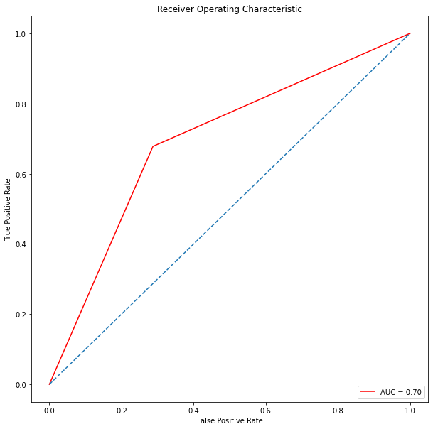

```
L'aire sous la courbe ROC :  0.6953339432753889
```

```python
draw_auroc(y_test_us, y_pred)
```

### Amélioration du modèle - entraînement sur le dataset complet avec les meilleurs hyperparamètres

```python
lr_tuned = LogisticRegression(
    penalty = lr_gs.best_params_["model__penalty"],
    l1_ratio = lr_gs.best_params_["model__l1_ratio"],
    C= lr_gs.best_params_["model__C"]
    )
```

```python
lr_tuned.fit(X_train, y_train)
```

```
LogisticRegression(C=1000.0, l1_ratio=0)
```

```python
# On récupère la prédiction de la valeur positive
y_prob_tuned = lr_tuned.predict_proba(X_test)[:,1]
```

### Résultats

```python
# On créé un vecteur de prédiction à partir du vecteur de probabilités
y_pred_tuned = np.where(y_prob_tuned > 0.5, 1, 0)
get_score(y_test, y_pred_tuned)
```

```
              precision    recall  f1-score   support

         0.0       0.93      1.00      0.96     28271
         1.0       0.00      0.00      0.00      2186

    accuracy                           0.93     30457
   macro avg       0.46      0.50      0.48     30457
weighted avg       0.86      0.93      0.89     30457


[[28271     0]
 [ 2186     0]]
```

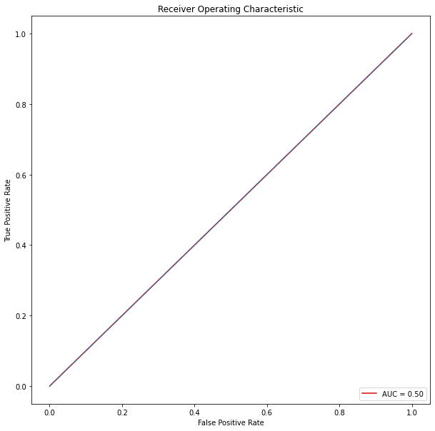

```
L'aire sous la courbe ROC :  0.5
```

```python
draw_auroc(y_test, y_pred_tuned)
```

## Support Vector Machine

### Définition

Le principe des SVM consiste à ramener un problème de classification ou de discrimination à un hyperplan (`feature space`) dans lequel les données sont séparées en plusieurs classes dont la frontière est la plus éloignée possible des points de données (ou "marge maximale"). D'où l'autre nom attribué aux SVM : les **séparateurs à vaste marge**.

Le concept de frontière implique que les données soient linéairement séparables. Pour y parvenir, les support vector machines **font appel à des noyaux**, c'est-à-dire des fonctions mathématiques permettant de projeter et séparer les données dans l'espace vectoriel, les `vecteurs de support` étant les données les plus proches de la frontière.

C'est la **frontière la plus éloignée de tous les points d'entraînement qui est optimale**, et qui présente donc la meilleure capacité de généralisation. ([source](https://www.journaldunet.fr/web-tech/guide-de-l-intelligence-artificielle/1501879-machine-a-vecteurs-de-support-svm-definition-et-cas-d-usage/)).

[figure not shown]

Représentations d'un linear SVC ([source](https://towardsdatascience.com/svm-feature-selection-and-kernels-840781cc1a6c))

### Recherche des hyperparamètres

- `penalty` : régularisation l1 ou l2.
- `C` : coefficient de régularisation.
- `loss` : fonction de coût.

### LinearSVC - GridSearch

```python
svm_model = LinearSVC(
    class_weight="balanced",
    dual=False,
    random_state=42)
```

```python
pipe = imbpipeline([
    ('scaler', RobustScaler()),
    ('model', svm_model)
])

params = {
            "model__penalty": ["l1","l2"],
            #"model__loss": ["hinge", "squared_hinge"], "ERROR : not supported when 'penalty' = l1"
            "model__C": [1,10,20]
        }
# Création du model qui va nous permettre de comparer nos jeux de données
gs_svm = GridSearchCV(
    pipe,
    params,
    cv = 4,
    scoring = score,
    n_jobs = -1, verbose = 1)

# On entraine et on évalue le modèle
gs_svm.fit(X_train_us, y_train_us)
```

```
Fitting 4 folds for each of 6 candidates, totalling 24 fits
```

```
GridSearchCV(cv=4,
             estimator=Pipeline(steps=[('scaler', RobustScaler()),
                                       ('model',
                                        LinearSVC(class_weight='balanced',
                                                  dual=False,
                                                  random_state=42))]),
             n_jobs=-1,
             param_grid={'model__C': [1, 10, 20],
                         'model__penalty': ['l1', 'l2']},
             scoring='roc_auc', verbose=1)
```

### Résultats

```python
pred_gs_svm = gs_svm.predict(X_test_us)

# print classification report
get_score(y_test_us, pred_gs_svm)
```

```
              precision    recall  f1-score   support

         0.0       0.69      0.71      0.70      2186
         1.0       0.70      0.69      0.69      2186

    accuracy                           0.70      4372
   macro avg       0.70      0.70      0.70      4372
weighted avg       0.70      0.70      0.70      4372


[[1555  631]
 [ 687 1499]]
```

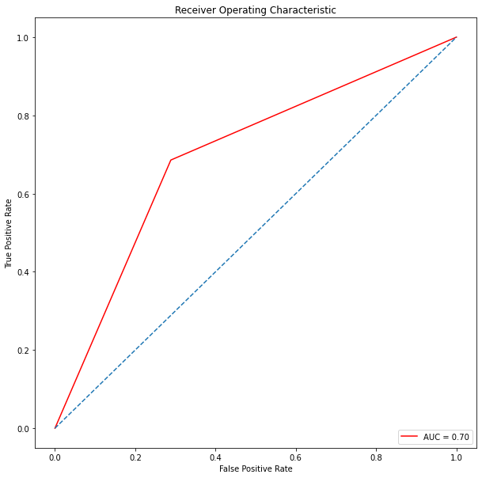

```
L'aire sous la courbe ROC :  0.6985361390667888
```

```python
draw_auroc(y_test_us, pred_gs_svm)
```

### Amélioration du modèle - entraînement sur le dataset complet avec les meilleurs hyperparamètres

```python
# On affiche les résultats
show_best(gs_svm)
```

```
Best parameters : {'model__C': 20, 'model__penalty': 'l1'}
Best score : 0.7681956646779481
```

```python
svm_tuned = LinearSVC(C=20)
svm_tuned.fit(X_train, y_train)
```

```
LinearSVC(C=20)
```

### Résultats

```python
pred_svm_tuned = svm_tuned.predict(X_test)

# print classification report
get_score(y_test, pred_svm_tuned)
```

```
              precision    recall  f1-score   support

         0.0       0.93      1.00      0.96     28271
         1.0       0.00      0.00      0.00      2186

    accuracy                           0.93     30457
   macro avg       0.46      0.50      0.48     30457
weighted avg       0.86      0.93      0.89     30457


[[28271     0]
 [ 2186     0]]
```

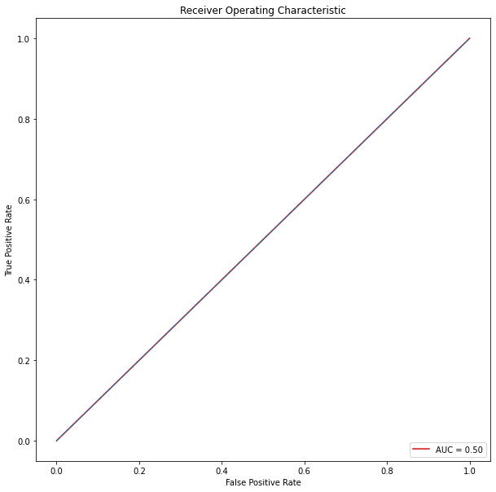

```
L'aire sous la courbe ROC :  0.5
```

```python
draw_auroc(y_test, pred_svm_tuned)
```